# Descriptive Statistics

Tell us what you know for certain

[Dr. Peng Zhao](https://connect.xjtlu.edu.cn/user/pengzhao) (✉ peng.zhao@xjtlu.edu.cn)

Department of Health and Environmental Sciences  
Xi’an Jiaotong-Liverpool University

# 1 Learning objectives

In this lecture, you will

1. know how to describe categorical data and numerical data, and
2. use appropriate tables and graphs for presenting categorical and numerical data.

# 2 Categorical data

Categorical data are often described with frequency/count and proportion.

## 2.1 One-way tables

| Cylinder | 4 | 6 | 8 |
| --- | --- | --- | --- |
| Count | 11 | 7 | 14 |

Visualization: bar plots and pie charts

## 2.2 Two-way tables

Contingency tables/cross-tabulation

```
 ----------------------------------------
        --------------gear---------------
 cyl           3       4       5   Total
 ----------------------------------------
 4             1       8       2      11
 6             2       4       1       7
 8            12       0       2      14

 Total        15      12       5      32
 ----------------------------------------
```

Visualization: bar plots

## 2.3 Three-way tables

| Gender |  | Male |  |  |  | Female |  |  |  |
| --- | --- | --- | --- | --- | --- | --- | --- | --- | --- |
|  |  | Eye |  |  |  |  |  |  |  |
|  |  | Brown | Blue | Hazel | Green | Brown | Blue | Hazel | Green |
| Hair | Black | 32 | 11 | 10 | 3 | 36 | 9 | 5 | 2 |
|  | Brown | 53 | 50 | 25 | 15 | 66 | 34 | 29 | 14 |
|  | Red | 10 | 10 | 7 | 7 | 16 | 7 | 7 | 7 |
|  | Blond | 3 | 30 | 5 | 8 | 4 | 64 | 5 | 8 |

# 3 Numerical data

## 3.1 Describe the center

- Mean
- Median

## 3.2 Describe the spread

- Generic Measure: Range
- Paired with the mean: variance, standard deviation
- Paired with the median: Quartiles/Percentiles

## 3.3 Visualizing the center and the spread

**Bar/Scatter plot:**

Usually with error bars

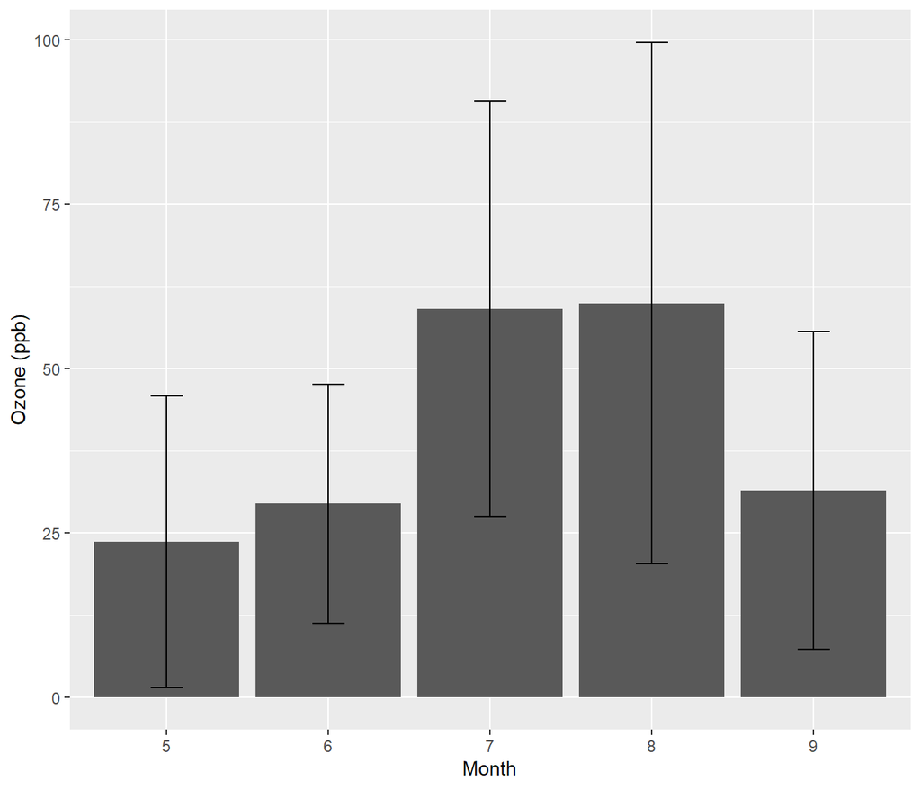

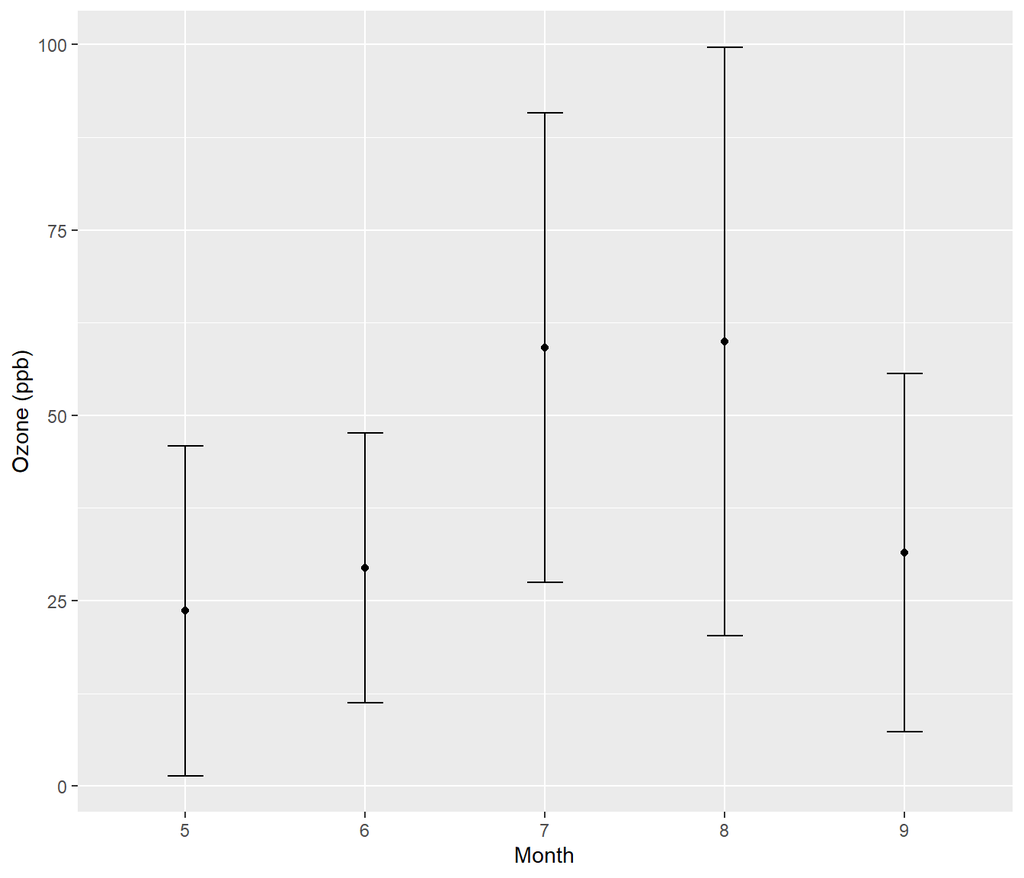

**Box plot (box-and-whisker plot):**

Show groups of numerical data through their quartiles, with lines extending from the boxes (whiskers) indicating variability outside the upper and lower quartiles.

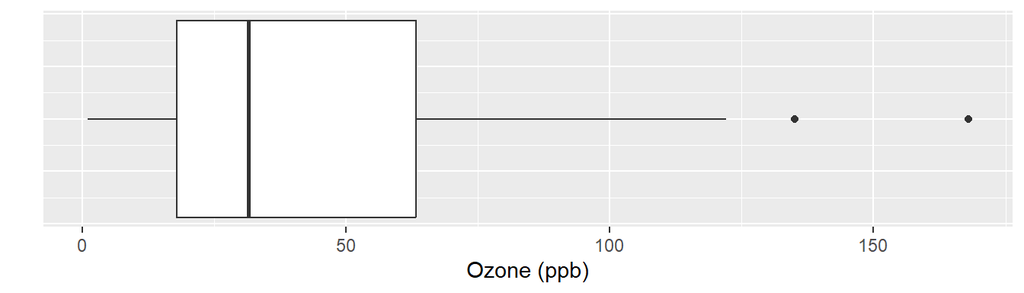

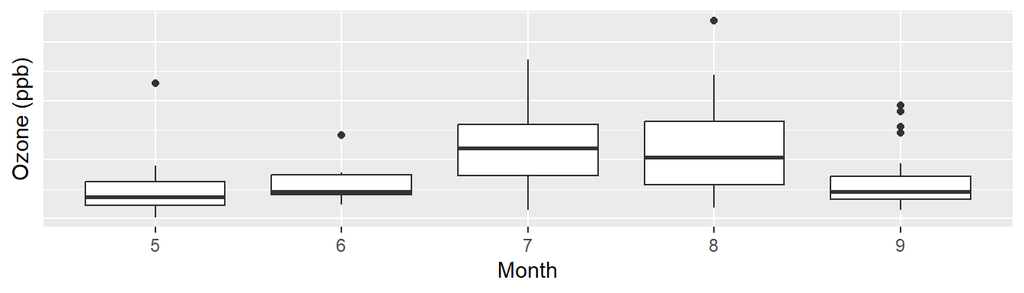

**Violin plot:**

a combination of a box plot and a density plot to show the distribution shape of the data

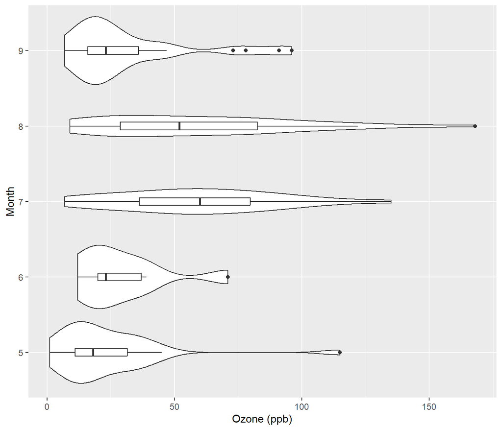

## 3.4 Describe the shape

**Skewness:**

Central symmetry - No skew - Left skew - Right skew

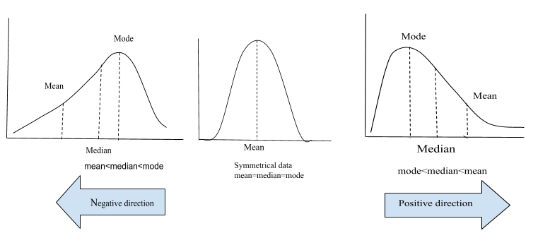

- skewness < -1: much left/negative skew.
- -1 < skewness < -0.5: moderately left/negative skew.
- -0.5 < skewness < 0.5: approximately symmetric.
- 0.5 < skewness < 1: moderately right/positive skew.
- 1 < skewness: much right/positive skew.

**Kurtosis:**

Peakedness - Leptokurtic distributions: tall and slender. - Platykurtic distributions: broad and flat.

[figure not shown]

- kurtosis < 0: platykurtic.
- kurtosis = 0: mesokurtic.–> normal distribution (-7 to +7, Bryne (2010)).
- kurtosis > 0: leptokurtic.

# 4 Reporting numerical data

Means and standard deviations:

- Average sample height was 136.4 cm (*SD* = 15.1).
- The height of the initial sample was relatively low (*M* = 125.9 cm, *SD* = 16.6).
- Height significantly varied between children aged 5–7, 8–10, and 11–13. The means were 115.3, 133.5, and 149.1 cm, respectively.

Median and interquartile range

- A median value of 54 (IQR 45-62)…
- The median (IQR) was 54 (45-62)…

# 5 Readings

- Natural Resources Biometrics
  - [Chapter 1: Descriptive Statistics and the Normal Distribution](https://courses.lumenlearning.com/suny-natural-resources-biometrics/chapter/chapter-1-descriptive-statistics-and-the-normal-distribution/)